# What’s an Apostille?

Here’s how I personally understand how Apostilles work.

general

Published

July 2, 2021

# What’s an Apostille?

Here’s how I personally understand how Apostilles work.

## The motivation

You live in a country called Pachaland, whose State issues its own official documents (like birth certificates, home ownership registries, etc….).

Within Pachaland, its own official documents are recognized: You get, say, a birth certificate at the Pachaland Citizen Registry, take it to the Pachaland Ministry of Education, and they’ll accept it.

This is how countries usually work.

But what happens if you want to take your Pachaland documents to a foreign country, called Extrostan?

To the authorities of Extrostan, Pachaland documents are just pieces of paper with some ink.

Yet if the Extrostan authorities need some information about you that only Pachaland can give, how can they be sure you are presenting a real Pachaland document?

To solve this problem, a group of countries [got together](https://en.wikipedia.org/wiki/Apostille_Convention), and decided on the following:

“Let us agree on a type of stamp we can all recognize, and let us attach this stamp to our own official documents!”

This is the origin story of the **Apostille**.

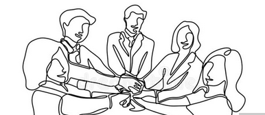

# Apostilles

Physically, Apostilles are an adhesive stamp with a lot of security features.

Diplomatically, an Apostille from Pachaland on a Pachaland document basically says:

“The Pachaland State hereby affirms that the document to which this Apostille is adhered, was issued/signed by a Pachaland Institution or Authority. We don’t affirm that the content is true, though, just that we printed it.”

Apostilles look like this:

(Example of a Peruvian Apostille, all names are fake)

[figure not shown]

They’re approx. 5 cm x 8 cm adhesive stamps, with usually the following data:

1. Name of the country
2. Who put his signature in this document?
3. What official position did that person have inside the State?
4. In which institution did that person work?
5. Where was this Apostille printed?
6. When was this Apostille printed?
7. By which authority was this Apostille printed?
8. Registration number of the Apostille
9. Seal with security features
10. Signature of the person (from the institution in 7) in charge of printing this Apostille.

So, a lot of official stuff.

Answers to question number 7 (who prints Apostilles?) vary from country to country. It could be the Ministry of Foreign Affairs (like in Peru), local Justice Tribunals (like in Brasil), etc… each country has its own system (and costs!), but they will all in the end print the same format of Apostille.

# Which documents can get an Apostille?

From what I know, there are four kinds of documents that can get an Apostille.

1. Documents issued by the State
2. Private documents (like a work or rent contract, etc….) that get some kind of State recognition (like being signed by a notary, etc….)
3. Certified copies of documents of kinds 1 or 2.
4. Official translations (with a registered translator) of documents of kinds 1, 2, and 3.

They’ll paste one Apostille per document. Even if the document has many pages, it will only get one Apostille.

Official translations get their own Apostille, in this way:

1. Get the original official document
2. Get the Apostille for the original official document
3. Get an official translation for the apostilled original official document
4. Get an Apostille for the translated document

A real hustle.

# My case

Getting an Apostille in Peru:

- Step 1: Get your document (duh!)
- Step 2: Research who prints Apostilles and what’s the procedure to get one.

In Peru, the Ministry of Foreign Affairs prints all Apostilles. Luckily for me, Apostilles for documents from educational institutions (schools, universities, etc) are free. For all other documents the payment must me done at the National Bank before getting an Apostille. The Ministry has its price list on its [website](http://portal.rree.gob.pe/sitepages/apostilla.aspx).

(being the Peruvian Government website, I’ll cross my fingers to the link not getting broken)

Pre-covid, the Ministry had many offices spread around the city. You just had to get there to start the process. For one or two documents, some offices would be very quick and (after quickly paying at a National Bank module there), they would get your Apostilles in less than 30 minutes. For more documents you would have to wait a couple of hours, and for a lot of documents, just return the next day. Good times!

During covid, the Ministry only works in its central office. You have to get an appointment at their (shitty) website. But because of the demand, they open new appointment slots at random, and the appointments will be in two or three months! Terrible! I reserved my appointment in November 2020 for January 2021. Just terrible!

For some stupid reason, this process can only be paid in cash in Peru.

### Example 1

I Apostilled my birth certificate. This was very straightforward.

1. I got my birth certificate at the Citizen Registry (RENIEC, in Peru)
2. I went to one of the Ministry of Foreign Affairs offices
3. I paid and waited for a few minutes
4. Done

### Example 2

The process for my Bachelor’s degree was not straightforward.

The issue: Bachelor’s degrees are not issued by the Peruvian State, but by universities.

How to get an Apostille for them then?

Well, in Peru, I needed a Registration Certificate from the Peruvian Higher Education Authority (SUNEDU) saying that my Bacherlor’s degree was in their registry.

Even though my Bachelor’s degree was not issued by the Peruvian State, this Registration Certificate was, so it could get an Apostille!

So my whole process was

1. I got the physical Bachelor’s degree
2. I got the Registration Certificate from the Peruvian Higher Education Authority
3. I went to the Ministry of Foreign Affairs to get an Apostille for the Registration Certificate
4. I paid and waited for a few hours (this was during covid)
5. Done

Luckily, getting the Registration Certificate can be done online now.

The people at the Ministry of Foreign Affairs didn’t even look at my Bachelor’s degree, just at the Registration Certificate, because for them the Registration Certificate was the only official document I gave them.

# Two exceptions

There are two cases when, due to international treaties, documents do not need to be Apostilled.

## Documents from Consulates

In principle, documents produced by consulated do not need to be apostilled, because they will contain official seals and security measures equivalent to an Apostille.

For example, imagine you are a foreigner living in France, and ask your consulate for a copy of your birth certificate. Your consulate will produce this document, with the official seal of the consulate, and this should be equivalent to a birth certificate produced and apostilled in your country. If you are lucky, they will produce the document in the local language, otherwhise, you will have to get an official translation, and an Apostille for this translation.

## Within the European Union

The members of the European Union accept several documents produced in other member states. This is important for Erasmus Mundus students that will move between countries of the European Union.

For example, imagine that you want to present a criminal record from France to the Spanish authorities. Then, at the moment of requesting the document (most bureaucracy of this kind can be done online), you also have to request a *supplementary form* for France. This supplementary form is a translation guide so that the Spanish authorities can read the French document. If you preesent the French document together with its supplementary form, then you do not need to get an Apostille nor a translation.

# Final notes.

Passports don’t need Apostilles!

Depending on where one is going and what one is doing, the requirements will be different. For example, almost no one requests Apostilled documents from tourists.

Countries that are not part of the [Apostille Convention](https://en.wikipedia.org/wiki/Apostille_Convention), use Legalization. Basically, a Legalization says “We pinky promise this document was issued by us”.

What’s the difference with an Apostille? Aren’t both made with the same purpose? Yeah, they both intend to show that a document was really issued by a country, the difference is that Apostilles have a format and security features all countries in the Apostille Convention will recognize, while each country that uses Legalization (because they’re outside the Convention) will have its own format, own security features, etc…

So I hope that give a general idea of what Apostilles are, and of the Kafkian ordeal it is to get an Apostille sometimes.

[figure not shown]

> Sadly not-needless to say, this is not legal nor any kind of advice, just my personal story. Don’t copy random strangers on the internet.